# Relatório 05

Nicolas Willian Ribeiro

12/05/2025

# 1 Objetivo

Selecionar o melhor modelo de modulação para um provedor de serviços de telecomunicações, levando em conta os diferentes bairros que o provedor atende.

# 2 Apresentação do relatório

O relatorio tem como objetivo mostrar os resultados de uma analise de Variância usando DBC para saber qual tipo de modulação se encaixa melhor no cenario e se a blocagem por bairros realmente influencía na analise.

Dados:

```
##    Bairro Modulacao  BER
## 1       1      QPSK 0.08
## 2       1     16QAM 0.11
## 3       1     64QAM 0.14
## 4       1      OFDM 0.07
## 5       2      QPSK 0.09
## 6       2     16QAM 0.12
## 7       2     64QAM 0.15
## 8       2      OFDM 0.06
## 9       3      QPSK 0.07
## 10      3     16QAM 0.10
## 11      3     64QAM 0.13
## 12      3      OFDM 0.08
## 13      4      QPSK 0.10
## 14      4     16QAM 0.13
## 15      4     64QAM 0.16
## 16      4      OFDM 0.09
## 17      5      QPSK 0.09
## 18      5     16QAM 0.12
## 19      5     64QAM 0.14
## 20      5      OFDM 0.07
```

Analise descritiva:

```
## Média geral: 0.105
```

```
## Desvio padrão geral: 0.02982405
```

```
## Coeficiente de variação (%): 28.40385
```

```
## # A tibble: 4 × 4
##   Modulacao Media     DP    CV
##   <fct>     <dbl>  <dbl> <dbl>
## 1 16QAM     0.116 0.0114  9.83
## 2 64QAM     0.144 0.0114  7.92
## 3 OFDM      0.074 0.0114 15.4
## 4 QPSK      0.086 0.0114 13.3
```

Grafico Boxplot:

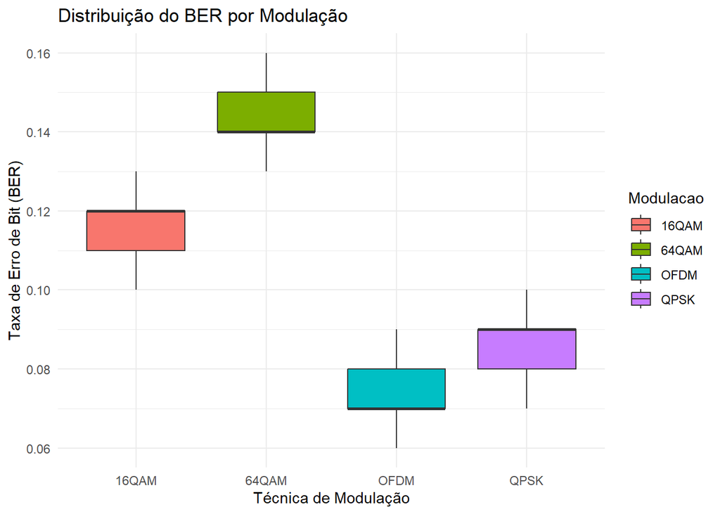

Analise de Variância utilizando DBC:

```
##             Df  Sum Sq  Mean Sq F value   Pr(>F)
## Modulacao    3 0.01482 0.004940  87.176 2.05e-08 ***
## Bairro       4 0.00140 0.000350   6.176  0.00615 **
## Residuals   12 0.00068 0.000057
## ---
## Signif. codes:  0 '***' 0.001 '**' 0.01 '*' 0.05 '.' 0.1 ' ' 1
```

Analise de Residuos:

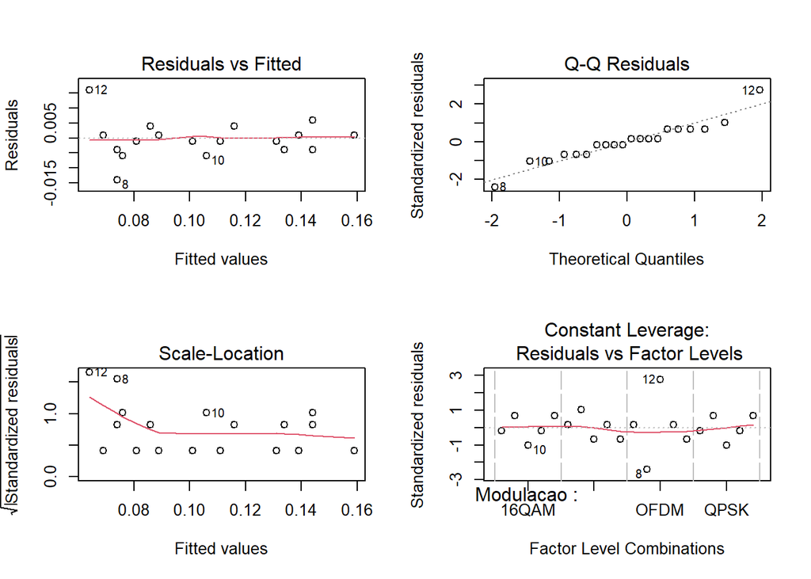

Comparações Múltiplas (Tukey):

```
## $statistics
##        MSerror Df  Mean       CV       MSD
##   5.666667e-05 12 0.105 7.169263 0.0141348
##
## $parameters
##    test    name.t ntr StudentizedRange alpha
##   Tukey Modulacao   4          4.19866  0.05
##
## $means
##         BER        std r          se  Min  Max  Q25  Q50  Q75
## 16QAM 0.116 0.01140175 5 0.003366502 0.10 0.13 0.11 0.12 0.12
## 64QAM 0.144 0.01140175 5 0.003366502 0.13 0.16 0.14 0.14 0.15
## OFDM  0.074 0.01140175 5 0.003366502 0.06 0.09 0.07 0.07 0.08
## QPSK  0.086 0.01140175 5 0.003366502 0.07 0.10 0.08 0.09 0.09
##
## $comparison
## NULL
##
## $groups
##         BER groups
## 64QAM 0.144      a
## 16QAM 0.116      b
## QPSK  0.086      c
## OFDM  0.074      c
##
## attr(,"class")
## [1] "group"
```

#Conclusão

Analisando o Boxplot já conseguimos ver duas modulações com alto indice de BER (Bit Error Rate) podemos então pressupor que existe diferença entre as modulações e que talvez a analise por blocos tenha surtido efeito e a analise de residuos nos mostra que tudo esta conforme o esperado, as amostras ficaram homogeneas.

Quando a melhor modulação temos duas modulações estatisticamente equivalentes QPSK e OFDM, sendo a OFDM a menor BER, nesse caso como elas são estatisticamente equivalentes pode se considerar o menor custo de implatação na hora de escolher qual delas utilizar.

#Curiosidade

Por curiosidade eu retirei a blocagem dessa analise para compararmos os resultados.

```
##             Df  Sum Sq Mean Sq F value   Pr(>F)
## Modulacao    3 0.01482 0.00494      38 1.66e-07 ***
## Residuals   16 0.00208 0.00013
## ---
## Signif. codes:  0 '***' 0.001 '**' 0.01 '*' 0.05 '.' 0.1 ' ' 1
```

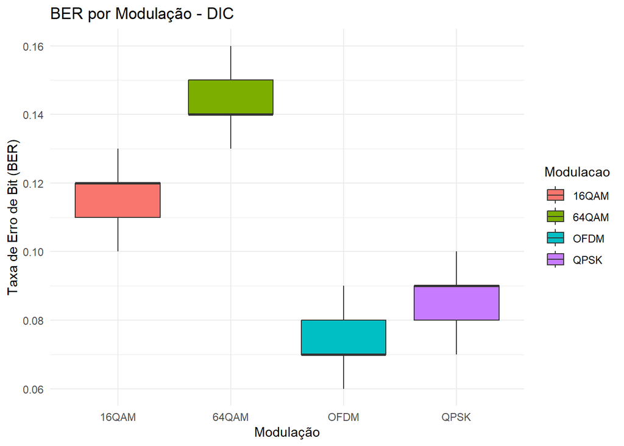

```
## $statistics
##   MSerror Df  Mean       CV        MSD
##   0.00013 16 0.105 10.85881 0.02063111
##
## $parameters
##    test    name.t ntr StudentizedRange alpha
##   Tukey Modulacao   4         4.046093  0.05
##
## $means
##         BER        std r         se  Min  Max  Q25  Q50  Q75
## 16QAM 0.116 0.01140175 5 0.00509902 0.10 0.13 0.11 0.12 0.12
## 64QAM 0.144 0.01140175 5 0.00509902 0.13 0.16 0.14 0.14 0.15
## OFDM  0.074 0.01140175 5 0.00509902 0.06 0.09 0.07 0.07 0.08
## QPSK  0.086 0.01140175 5 0.00509902 0.07 0.10 0.08 0.09 0.09
##
## $comparison
## NULL
##
## $groups
##         BER groups
## 64QAM 0.144      a
## 16QAM 0.116      b
## QPSK  0.086      c
## OFDM  0.074      c
##
## attr(,"class")
## [1] "group"
```

#Comentarios